# Saumya Kothari - Natural Language Processing Project 2 (Part 1)

## Part 1

### DOMAIN:

Digital content and entertainment industry

### CONTEXT:

The objective of this project is to build a text classification model that analyses the customer's sentiments based on their reviews in the IMDB database. The model uses a complex deep learning model to build an embedding layer followed by a classification algorithm to analyse the sentiment of the customers.

### DATA DESCRIPTION:

The Dataset of 50,000 movie reviews from IMDB, labelled by sentiment (positive/negative). Reviews have been preprocessed, and each review is encoded as a sequence of word indexes (integers). For convenience, the words are indexed by their frequency in the dataset, meaning the for that has index 1 is the most frequent word. Use the first 20 words from each review to speed up training, using a max vocabulary size of 10,000. As a convention, "0" does not stand for a specific word, but instead is used to encode any unknown word.

### PROJECT OBJECTIVE:

Build a sequential NLP classifier which can use input text parameters to determine the customer sentiments. Steps and tasks: [ Total Score: 30 points]

1. Import and analyse the data set. Hint:
   - Use `imdb.load_data()` method
   - Get train and test set
   - Take 10000 most frequent words
2. Perform relevant sequence adding on the data
3. Perform following data analysis: • Print shape of features and labels • Print value of any one feature and it's label
4. Decode the feature value to get original sentence
5. Design, train, tune and test a sequential model. Hint: The aim here Is to import the text, process it such a way that it can be taken as an inout to the ML/NN classifiers. Be analytical and experimental here in trying new approaches to design the best model.
6. Use the designed model to print the prediction on any one sample.

#### Importing Neccessary packages

```python
import pandas as pd
import numpy as np
from bs4 import BeautifulSoup
import matplotlib.pyplot as plt
import seaborn as sns
```

#### Loading IMDB Dataset

```python
from keras.datasets import imdb
df = pd.read_csv("IMDB_Dataset.csv")
```

#### Exploratory Data Analysis

```python
df.head()
```

|  | review | sentiment |
| --- | --- | --- |
| 0 | One of the other reviewers has mentioned that ... | positive |
| 1 | A wonderful little production. <br /><br />The... | positive |
| 2 | I thought this was a wonderful way to spend ti... | positive |
| 3 | Basically there's a family where a little boy ... | negative |
| 4 | Petter Mattei's "Love in the Time of Money" is... | positive |

```python
df.shape
```

```
(50000, 2)
```

```python
df = df.head(10000)
```

```python
df.shape
```

```
(10000, 2)
```

```python
df.isnull().sum()
```

```
review       0
sentiment    0
dtype: int64
```

```python
df['sentiment'].value_counts()
```

```
positive    5028
negative    4972
Name: sentiment, dtype: int64
```

##### Note:

Dataset is almost balanced. There are 5028 reviews for positive sentiments and 4972 for negative sentiments.

```python
##New column for length of review
df['length']=df['review'].str.len()
```

```python
#Displaying maximum col width
pd.set_option('display.max_colwidth', None)
```

```python
df.head()
```

|  | review | sentiment | length |
| --- | --- | --- | --- |
| 0 | One of the other reviewers has mentioned that after watching just 1 Oz episode you'll be hooked. They are right, as this is exactly what happened with me.<br /><br />The first thing that struck me abo… | positive | 1761 |
| 1 | A wonderful little production. <br /><br />The filming technique is very unassuming- very old-time-BBC fashion and gives a comforting, and sometimes discomforting, sense of realism to the entire piece… | positive | 998 |
| 2 | I thought this was a wonderful way to spend time on a too hot summer weekend, sitting in the air conditioned theater and watching a light-hearted comedy. The plot is simplistic, but the dialogue is wi… | positive | 926 |
| 3 | Basically there's a family where a little boy (Jake) thinks there's a zombie in his closet & his parents are fighting all the time.<br /><br />This movie is slower than a soap opera... and suddenly, J… | negative | 748 |
| 4 | Petter Mattei's "Love in the Time of Money" is a visually stunning film to watch. Mr. Mattei offers us a vivid portrait about human relations. This is a movie that seems to be telling us what money, p… | positive | 1317 |

```python
#Removing html tags

def removehtml(text):
    soup=BeautifulSoup(text)
    return soup.get_text()

df['review']=df['review'].apply(removehtml)
```

```python
#Converting into lower case

df['review']=df['review'].str.lower()
```

```python
#Replacing everthing except alpabets and numbers with space

df['review']=df['review'].str.replace(r'[^a-zA-Z0-9]',' ')
```

```python
from nltk.corpus import stopwords
from nltk.stem import SnowballStemmer
sw=set(stopwords.words('english'))
snow=SnowballStemmer('english')
```

```python
#Removing stop words and performimg stemming

def stemming(text):
    text=' '.join([snow.stem(word) for word in text.split() if word not in sw])
    return text

df['review']=df['review'].apply(stemming)
```

```python
df.head()
```

|  | review | sentiment | length |
| --- | --- | --- | --- |
| 0 | one review mention watch 1 oz episod hook right exact happen first thing struck oz brutal unflinch scene violenc set right word go trust show faint heart timid show pull punch regard drug sex violenc … | positive | 1761 |
| 1 | wonder littl product film techniqu unassum old time bbc fashion give comfort sometim discomfort sens realism entir piec actor extrem well chosen michael sheen got polari voic pat truli see seamless ed… | positive | 998 |
| 2 | thought wonder way spend time hot summer weekend sit air condit theater watch light heart comedi plot simplist dialogu witti charact likabl even well bread suspect serial killer may disappoint realiz … | positive | 926 |
| 3 | basic famili littl boy jake think zombi closet parent fight time movi slower soap opera sudden jake decid becom rambo kill zombi ok first go make film must decid thriller drama drama movi watchabl par… | negative | 748 |
| 4 | petter mattei love time money visual stun film watch mr mattei offer us vivid portrait human relat movi seem tell us money power success peopl differ situat encount variat arthur schnitzler play theme… | positive | 1317 |

```python
#Label coding 0 and 1

df['sentiment'].replace({'negative':0,'positive':1},inplace=True)
```

```python
df.head()
```

|  | review | sentiment | length |
| --- | --- | --- | --- |
| 0 | one review mention watch 1 oz episod hook right exact happen first thing struck oz brutal unflinch scene violenc set right word go trust show faint heart timid show pull punch regard drug sex violenc … | 1 | 1761 |
| 1 | wonder littl product film techniqu unassum old time bbc fashion give comfort sometim discomfort sens realism entir piec actor extrem well chosen michael sheen got polari voic pat truli see seamless ed… | 1 | 998 |
| 2 | thought wonder way spend time hot summer weekend sit air condit theater watch light heart comedi plot simplist dialogu witti charact likabl even well bread suspect serial killer may disappoint realiz … | 1 | 926 |
| 3 | basic famili littl boy jake think zombi closet parent fight time movi slower soap opera sudden jake decid becom rambo kill zombi ok first go make film must decid thriller drama drama movi watchabl par… | 0 | 748 |
| 4 | petter mattei love time money visual stun film watch mr mattei offer us vivid portrait human relat movi seem tell us money power success peopl differ situat encount variat arthur schnitzler play theme… | 1 | 1317 |

```python
#New column (clean length) after removal of punctuations and stopwords

df['clean_length']=df['review'].str.len()
```

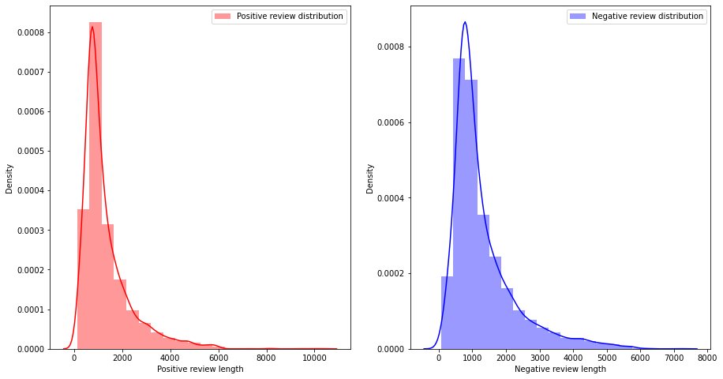

```python
#Message distribution before cleaning

f,ax=plt.subplots(1,2,figsize=(15,8))

sns.distplot(df[df['sentiment']==1]['length'],bins=20,ax=ax[0],label='Positive review distribution',color='r')

ax[0].set_xlabel('Positive review length')
ax[0].legend()

sns.distplot(df[df['sentiment']==0]['length'],bins=20,ax=ax[1],label='Negative review distribution',color='b')

ax[1].set_xlabel('Negative review length')
ax[1].legend()

plt.show()
```

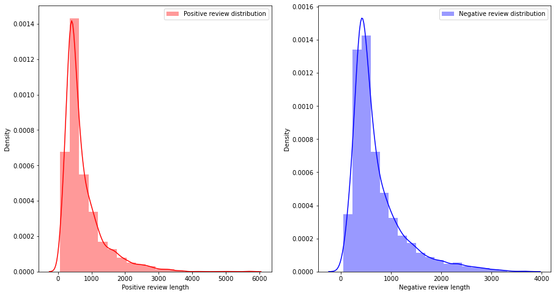

```python
#Message distribution before cleaning

f,ax=plt.subplots(1,2,figsize=(15,8))

sns.distplot(df[df['sentiment']==1]['clean_length'],bins=20,ax=ax[0],label='Positive review distribution',color='r')

ax[0].set_xlabel('Positive review length')
ax[0].legend()

sns.distplot(df[df['sentiment']==0]['clean_length'],bins=20,ax=ax[1],label='Negative review distribution',color='b')

ax[1].set_xlabel('Negative review length')
ax[1].legend()

plt.show()
```

```python
from wordcloud import WordCloud
```

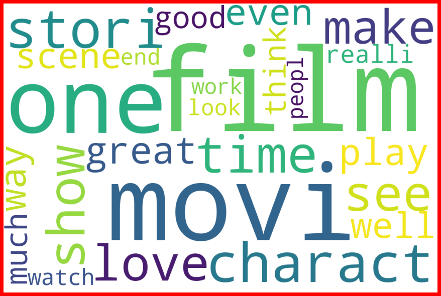

```python
#Getting sense of loud words in positive sentiments

positive=df['review'][df['sentiment']==1]
spamcloud=WordCloud(width=1200,height=800,background_color='white',max_words=25).generate(' '.join(positive))

plt.figure(figsize=(12,8),facecolor='r')
plt.imshow(spamcloud)
plt.axis('off')
plt.tight_layout(pad=0)
plt.show()
```

##### Note:

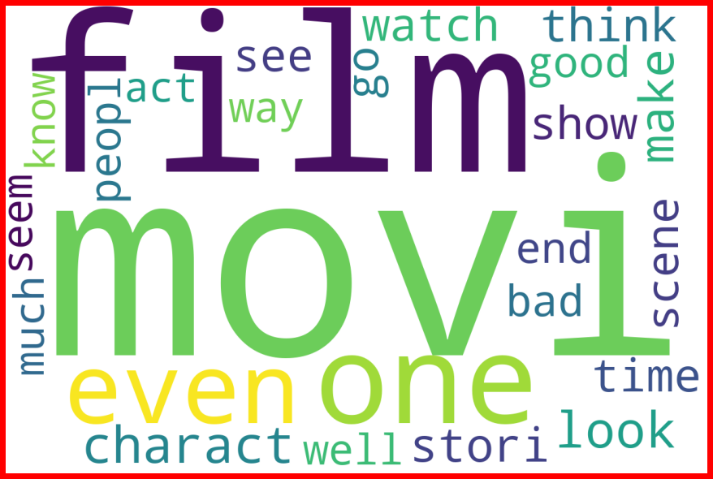

```python
#Getting sense of loud words in negative sentiments

negative=df['review'][df['sentiment']==0]
spamcloud=WordCloud(width=1200,height=800,background_color='white',max_words=25).generate(' '.join(negative))

plt.figure(figsize=(12,8),facecolor='r')
plt.imshow(spamcloud)
plt.axis('off')
plt.tight_layout(pad=0)
plt.show()
```

##### Note:

Negative reviews have word like see, look etc.

```python
from sklearn.feature_extraction.text import TfidfVectorizer
```

```python
review=df['review']
tfidf=TfidfVectorizer(ngram_range=(1,3))
review=tfidf.fit_transform(review)
```

```python
sentiment=df['sentiment']
```

```python
from sklearn.model_selection import train_test_split
from sklearn.ensemble import RandomForestClassifier
from xgboost import XGBClassifier
from sklearn.metrics import accuracy_score, classification_report, confusion_matrix
```

```python
xtrain,xtest,ytrain,ytest=train_test_split(review,sentiment,test_size=0.3,random_state=7)
```

#### Random Forest

```python
model=RandomForestClassifier()
model.fit(xtrain,ytrain)
```

```
RandomForestClassifier()
```

```python
p=model.predict(xtest)
```

```python
print('Accuracy score', accuracy_score(p,ytest))
print('-----------------------------------------')
print('Confusion Matrix')
print(confusion_matrix(p,ytest))
print('-----------------------------------------')
print('Classification Report')
print(classification_report(p,ytest))
```

```
Accuracy score 0.827
-----------------------------------------
Confusion Matrix
[[1159  163]
 [ 356 1322]]
-----------------------------------------
Classification Report
              precision    recall  f1-score   support

           0       0.77      0.88      0.82      1322
           1       0.89      0.79      0.84      1678

    accuracy                           0.83      3000
   macro avg       0.83      0.83      0.83      3000
weighted avg       0.84      0.83      0.83      3000
```

#### XGBoost

```python
model=XGBClassifier(verbosity=0)
model.fit(xtrain,ytrain)
```

```
XGBClassifier(base_score=0.5, booster='gbtree', colsample_bylevel=1,
              colsample_bynode=1, colsample_bytree=1, gamma=0, gpu_id=-1,
              importance_type='gain', interaction_constraints='',
              learning_rate=0.300000012, max_delta_step=0, max_depth=6,
              min_child_weight=1, missing=nan, monotone_constraints='()',
              n_estimators=100, n_jobs=4, num_parallel_tree=1, random_state=0,
              reg_alpha=0, reg_lambda=1, scale_pos_weight=1, subsample=1,
              tree_method='exact', validate_parameters=1, verbosity=0)
```

```python
p=model.predict(xtest)
```

```python
print('Accuracy score', accuracy_score(p,ytest))
print('-----------------------------------------')
print('Confusion Matrix')
print(confusion_matrix(p,ytest))
print('-----------------------------------------')
print('Classification Report')
print(classification_report(p,ytest))
```

```
Accuracy score 0.8396666666666667
-----------------------------------------
Confusion Matrix
[[1252  218]
 [ 263 1267]]
-----------------------------------------
Classification Report
              precision    recall  f1-score   support

           0       0.83      0.85      0.84      1470
           1       0.85      0.83      0.84      1530

    accuracy                           0.84      3000
   macro avg       0.84      0.84      0.84      3000
weighted avg       0.84      0.84      0.84      3000
```

##### Note:

From above, we can conclude that XGBoost works slightly better than Random Forest

#### Function to perform relevant sequence adding on the data

```python
from keras.datasets import imdb
(X_train, y_train), (X_test, y_test) = imdb.load_data(num_words=10000)
```

```
<__array_function__ internals>:5: VisibleDeprecationWarning: Creating an ndarray from ragged nested sequences (which is a list-or-tuple of lists-or-tuples-or ndarrays with different lengths or shapes) is deprecated. If you meant to do this, you must specify 'dtype=object' when creating the ndarray
```

```python
def vectorize(sequences, dimension = 10000):
    results = np.zeros((len(sequences), dimension))
    for i, sequence in enumerate(sequences):
        results[i, sequence] = 1
    return results
```

```python
#consolidating data for EDA
data = np.concatenate((X_train, X_test), axis=0)
label = np.concatenate((y_train, y_test), axis=0)
```

```python
print("Categories:", np.unique(label))
print("Number of unique words:", len(np.unique(np.hstack(data))))
```

```
Categories: [0 1]
Number of unique words: 9998
```

```python
length = [len(i) for i in data]
print("Average Review length:", np.mean(length))
print("Standard Deviation:", round(np.std(length)))
```

```
Average Review length: 234.75892
Standard Deviation: 173
```

##### Let's look at a single training example:

```python
print("Label:", label[0])
```

```
Label: 1
```

```python
print(data[0])
```

```
[1, 14, 22, 16, 43, 530, 973, 1622, 1385, 65, 458, 4468, 66, 3941, 4, 173, 36, 256, 5, 25, 100, 43, 838, 112, 50, 670, 2, 9, 35, 480, 284, 5, 150, 4, 172, 112, 167, 2, 336, 385, 39, 4, 172, 4536, 1111, 17, 546, 38, 13, 447, 4, 192, 50, 16, 6, 147, 2025, 19, 14, 22, 4, 1920, 4613, 469, 4, 22, 71, 87,…
```

##### Let's decode the first review

```python
index = imdb.get_word_index()
reverse_index = dict([(value, key) for (key, value) in index.items()])
decoded = " ".join( [reverse_index.get(i - 3, "#") for i in data[0]] )
print(decoded)
```

```
Downloading data from https://storage.googleapis.com/tensorflow/tf-keras-datasets/imdb_word_index.json
# this film was just brilliant casting location scenery story direction everyone's really suited the part they played and you could just imagine being there robert # is an amazing actor and now the same being director # father came from the same scottish island as myself so i loved the fact there wa…
```

```python
#Adding sequence to data
data = vectorize(data)
label = np.array(label).astype("float32")
```

```python
label
```

```
array([1., 0., 0., ..., 0., 0., 0.], dtype=float32)
```

### Train & Test Split

```python
# Import packages
import pandas as pd, numpy as np
import tensorflow as tf
assert tf.__version__ >= '2.0'

from itertools import islice

# Keras
from keras.layers import Dense, Embedding, LSTM, Dropout, MaxPooling1D, Conv1D
from keras.preprocessing.sequence import pad_sequences
from keras.models import Model, Sequential
from keras.preprocessing import sequence
from keras.datasets import imdb

from keras.callbacks import ModelCheckpoint, EarlyStopping

from sklearn.model_selection import train_test_split
from sklearn.metrics import classification_report

# Suppress warnings
import warnings; warnings.filterwarnings('ignore')

random_state = 42
np.random.seed(random_state)
tf.random.set_seed(random_state)
```

```python
vocab_size = 10000
maxlen = 300
(x_train, y_train), (x_test, y_test) = imdb.load_data(num_words = vocab_size)

x_train = pad_sequences(x_train, maxlen = maxlen, padding = 'pre')
x_test =  pad_sequences(x_test, maxlen = maxlen, padding = 'pre')

X = np.concatenate((x_train, x_test), axis = 0)
y = np.concatenate((y_train, y_test), axis = 0)

x_train, x_test, y_train, y_test = train_test_split(X, y, test_size = 0.2, random_state = random_state, shuffle = True)
x_train, x_valid, y_train, y_valid = train_test_split(x_train, y_train, test_size = 0.2, random_state = random_state, shuffle = True)

print('---'*20, f'\nNumber of rows in training dataset: {x_train.shape[0]}')
print(f'Number of columns in training dataset: {x_train.shape[1]}')
print(f'Number of unique words in training dataset: {len(np.unique(np.hstack(x_train)))}')


print('---'*20, f'\nNumber of rows in validation dataset: {x_valid.shape[0]}')
print(f'Number of columns in validation dataset: {x_valid.shape[1]}')
print(f'Number of unique words in validation dataset: {len(np.unique(np.hstack(x_valid)))}')


print('---'*20, f'\nNumber of rows in test dataset: {x_test.shape[0]}')
print(f'Number of columns in test dataset: {x_test.shape[1]}')
print(f'Number of unique words in test dataset: {len(np.unique(np.hstack(x_test)))}')


print('---'*20, f'\nUnique Categories: {np.unique(y_train), np.unique(y_valid), np.unique(y_test)}')
```

```
------------------------------------------------------------
Number of rows in training dataset: 32000
Number of columns in training dataset: 300
Number of unique words in training dataset: 9999
------------------------------------------------------------
Number of rows in validation dataset: 8000
Number of columns in validation dataset: 300
Number of unique words in validation dataset: 9984
------------------------------------------------------------
Number of rows in test dataset: 10000
Number of columns in test dataset: 300
Number of unique words in test dataset: 9995
------------------------------------------------------------
Unique Categories: (array([0, 1], dtype=int64), array([0, 1], dtype=int64), array([0, 1], dtype=int64))
```

### Get word index and create a key-value pair for word and word id

```python
def decode_review(x, y):
  w2i = imdb.get_word_index()
  w2i = {k:(v + 3) for k, v in w2i.items()}
  w2i['<PAD>'] = 0
  w2i['<START>'] = 1
  w2i['<UNK>'] = 2
  i2w = {i: w for w, i in w2i.items()}

  ws = (' '.join(i2w[i] for i in x))
  print(f'Review: {ws}')
  print(f'Actual Sentiment: {y}')
  return w2i, i2w

w2i, i2w = decode_review(x_train[0], y_train[0])

# get first 50 key, value pairs from id to word dictionary
print('---'*30, '\n', list(islice(i2w.items(), 0, 50)))
```

```
Review: <PAD> <PAD> <PAD> <PAD> <PAD> <PAD> <PAD> <PAD> <PAD> <PAD> <PAD> <PAD> <PAD> <PAD> <PAD> <PAD> <PAD> <PAD> <PAD> <PAD> <PAD> <PAD> <PAD> <PAD> <PAD> <PAD> <PAD> <PAD> <PAD> <PAD> <PAD> <PAD> <PAD> <PAD> <PAD> <PAD> <PAD> <PAD> <PAD> <PAD> <PAD> <PAD> <PAD> <PAD> <PAD> <PAD> <PAD> <PAD> <PAD…
Actual Sentiment: 0
------------------------------------------------------------------------------------------
 [(34704, 'fawn'), (52009, 'tsukino'), (52010, 'nunnery'), (16819, 'sonja'), (63954, 'vani'), (1411, 'woods'), (16118, 'spiders'), (2348, 'hanging'), (2292, 'woody'), (52011, 'trawling'), (52012, "hold's"), (11310, 'comically'), (40833, 'localized'), (30571, 'disobeying'), (52013, "'royale"), (40834…
```

### Build Keras Embedding Layer Model

We can think of the Embedding layer as a dicionary that maps a index assigned to a word to a word vector. This layer is very flexible and can be used in a few ways:

- The embedding layer can be used at the start of a larger deep learning model.
- Also we could load pre-train word embeddings into the embedding layer when we create our model.
- Use the embedding layer to train our own word2vec models.

The keras embedding layer doesn't require us to onehot encode our words, instead we have to give each word a unqiue intger number as an id. For the imdb dataset we've loaded this has already been done, but if this wasn't the case we could use sklearn LabelEncoder.

```python
# Model

model = Sequential()
model.add(Embedding(vocab_size, 256, input_length = maxlen))
model.add(Dropout(0.25))
model.add(Conv1D(256, 5, padding = 'same', activation = 'relu', strides = 1))
model.add(Conv1D(128, 5, padding = 'same', activation = 'relu', strides = 1))
model.add(MaxPooling1D(pool_size = 2))
model.add(Conv1D(64, 5, padding = 'same', activation = 'relu', strides = 1))
model.add(MaxPooling1D(pool_size = 2))
model.add(LSTM(75))
model.add(Dense(1, activation = 'sigmoid'))
model.compile(loss = 'binary_crossentropy', optimizer = 'adam', metrics = ['accuracy'])
print(model.summary())

# Adding callbacks

es = EarlyStopping(monitor = 'val_loss', mode = 'min', verbose = 1, patience = 0)
mc = ModelCheckpoint('imdb_model.h5', monitor = 'val_loss', mode = 'min', save_best_only = True, verbose = 1)
```

```
Model: "sequential"
_________________________________________________________________
Layer (type)                 Output Shape              Param #
=================================================================
embedding (Embedding)        (None, 300, 256)          2560000
_________________________________________________________________
dropout (Dropout)            (None, 300, 256)          0
_________________________________________________________________
conv1d (Conv1D)              (None, 300, 256)          327936
_________________________________________________________________
conv1d_1 (Conv1D)            (None, 300, 128)          163968
_________________________________________________________________
max_pooling1d (MaxPooling1D) (None, 150, 128)          0
_________________________________________________________________
conv1d_2 (Conv1D)            (None, 150, 64)           41024
_________________________________________________________________
max_pooling1d_1 (MaxPooling1 (None, 75, 64)            0
_________________________________________________________________
lstm (LSTM)                  (None, 75)                42000
_________________________________________________________________
dense (Dense)                (None, 1)                 76
=================================================================
Total params: 3,135,004
Trainable params: 3,135,004
Non-trainable params: 0
_________________________________________________________________
None
```

```python
# Fit the model
model.fit(x_train, y_train, validation_data = (x_valid, y_valid), epochs = 3, batch_size = 64, verbose = True, callbacks = [es, mc])

# Evaluate the model
scores = model.evaluate(x_test, y_test, batch_size = 64)
print('Test accuracy: %.2f%%' % (scores[1]*100))
```

```
Epoch 00001: val_loss improved from inf to 0.24461, saving model to imdb_model.h5

Epoch 00002: val_loss did not improve from 0.24461
Epoch 00002: early stopping
Test accuracy: 90.27%
```

```python
y_pred = model.predict_classes(x_test)
print(f'Classification Report:\n{classification_report(y_pred, y_test)}')
```

```
Classification Report:
              precision    recall  f1-score   support

           0       0.92      0.88      0.90      5125
           1       0.88      0.92      0.90      4875

    accuracy                           0.90     10000
   macro avg       0.90      0.90      0.90     10000
weighted avg       0.90      0.90      0.90     10000
```

#### Retrive output of each layer in keras for a given single test sample from the trained model

```python
sample_x_test = x_test[np.random.randint(10000)]
for layer in model.layers:

    model_layer = Model(inputs = model.input, outputs = model.get_layer(layer.name).output)
    output = model_layer.predict(sample_x_test.reshape(1,-1))
    print('\n','--'*20, layer.name, 'layer', '--'*20, '\n')
    print(output)
```

[output not shown]

[output cut: 52 more lines]

[output not shown]

```python
decode_review(x_test[10], y_test[10])
print(f'Predicted sentiment: {y_pred[10][0]}')
```

```
Review: <PAD> <PAD> <PAD> <PAD> <PAD> <PAD> <PAD> <PAD> <PAD> <PAD> <PAD> <PAD> <PAD> <PAD> <PAD> <PAD> <PAD> <PAD> <PAD> <PAD> <PAD> <PAD> <PAD> <PAD> <PAD> <PAD> <PAD> <PAD> <PAD> <PAD> <PAD> <PAD> <PAD> <PAD> <PAD> <PAD> <PAD> <PAD> <PAD> <PAD> <PAD> <PAD> <PAD> <PAD> <PAD> <PAD> <PAD> <PAD> <PAD…
Actual Sentiment: 1
Predicted sentiment: 1
```

## Conclusion:

Sentiment classification task on the IMDB dataset, on test dataset,

- Accuracy: > 90%
- F1-score: > 90%
- Loss of 0.25